# Yuxuan Gou-final project

Yuxuan (Rebecca)

2026-03-11

Descriptive anaysis and EDA

```r
#write.xlsx(data1, "data1.xlsx")
library(readxl)
data1<-read_excel("data1.xlsx")

data1
```

```
## # A tibble: 30,054 × 406
##     序号 提交答卷时间       所用时间 来源  来源详情 `问卷来自：` 来自IP    备注
##    <dbl> <chr>              <chr>    <chr> <chr>    <chr>        <chr>     <chr>
##  1    57 2023/6/20 20:33:39 1275     微信  N/A      社区         117.136.… <NA>
##  2    62 2023/6/20 20:47:48 2731     微信  N/A      社区         1.48.202… <NA>
##  3    68 2023/6/20 21:02:22 1319     微信  N/A      社区         223.104.… <NA>
##  4    71 2023/6/20 21:22:07 1310     微信  N/A      社区         114.106.… <NA>
##  5    75 2023/6/20 21:46:04 2382     微信  N/A      社区         219.143.… <NA>
##  6    76 2023/6/20 21:47:56 1728     微信  N/A      社区         106.108.… <NA>
##  7    77 2023/6/20 21:51:22 1580     微信  N/A      社区         111.18.1… <NA>
##  8    80 2023/6/20 21:58:34 秀米     微信  N/A      社区         124.89.6… <NA>
##  9    84 2023/6/20 22:06:16 2515     微信  N/A      社区         111.18.1… <NA>
## 10    90 2023/6/20 22:17:11 1309     微信  N/A      社区         111.227.… <NA>
## # ℹ 30,044 more rows
## # ℹ 398 more variables:
## #   `1、如果您同意参加我们的调查，请您点击下面的同意，并开始问卷调查。` <chr>,
## #   `2、问卷编号:` <chr>, `3、您的性别:` <chr>, `4、您的民族:` <chr>,
## #   `5、您是否有宗教信仰:` <chr>, `6、您的身高（单位:厘米cm） :` <dbl>,
## #   `7、您的体重（单位:公斤） :` <dbl>, `8、您的腰围（厘米cm）:` <chr>,
## #   `9、您的政治面貌:` <chr>, `10、您目前的职业状态:` <chr>, …
```

```r
library(dplyr)
```

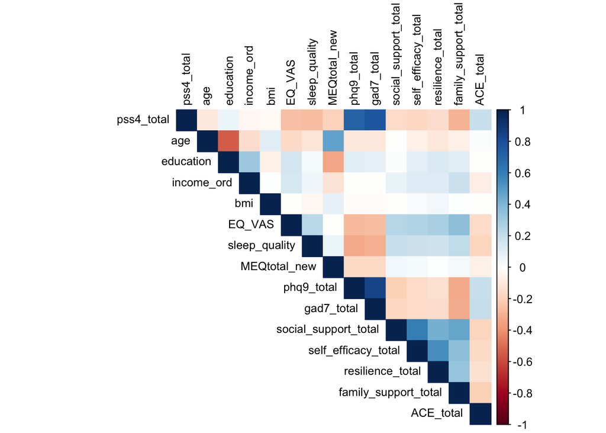

```r
library(corrplot)
corr_data <- data1 |>
  select(
    pss4_total, age, education, income_ord, bmi, EQ_VAS,
    sleep_quality, MEQtotal_new, phq9_total, gad7_total,
    social_support_total, self_efficacy_total,
    resilience_total, family_support_total, ACE_total
  )

corr_mat <- cor(corr_data, use = "pairwise.complete.obs")

corrplot(
  corr_mat,
  method = "color",
  type = "upper",
  tl.col = "black",
  tl.cex = 0.8
)
```

```r
dir.create("figs", showWarnings = FALSE)

png("figs/correlation_matrix.png", width = 1600, height = 1400, res = 200)

corrplot(
  corr_mat,
  method = "color",
  type = "upper",
  tl.col = "black",
  tl.cex = 0.8
)

dev.off()
```

```r
library(dplyr)
library(tidyr)
library(openxlsx)

# Create a folder to save the output
dir.create("output", showWarnings = FALSE)

# -----------------------------
# Table 2A: continuous variables
# -----------------------------
# These are the continuous variables we want to summarize
continuous_vars <- c(
  "pss4_total", "age", "education", "income_ord", "bmi", "EQ_VAS",
  "sleep_quality", "MEQtotal_new", "phq9_total", "gad7_total",
  "social_support_total", "self_efficacy_total",
  "resilience_total", "family_support_total", "ACE_total"
)

# Calculate mean, SD, min, max, and correlation with perceived stress
table2a <- data1 |>
  select(all_of(continuous_vars)) |>
  summarise(
    across(
      everything(),
      list(
        Mean = ~mean(.x, na.rm = TRUE),
        SD   = ~sd(.x, na.rm = TRUE),
        Min  = ~min(.x, na.rm = TRUE),
        Max  = ~max(.x, na.rm = TRUE)
      )
    )
  ) |>
  pivot_longer(
    cols = everything(),
    names_to = c("Variable", ".value"),
    names_sep = "_(?=[^_]+$)"
  ) |>
  mutate(
    `Correlation with perceived stress` = sapply(Variable, function(v) {
      if (v == "pss4_total") {
        NA
      } else {
        cor(data1[[v]], data1$pss4_total, use = "pairwise.complete.obs")
      }
    })
  )

# Replace code-style names with cleaner labels
table2a$Variable <- dplyr::recode(
  table2a$Variable,
  pss4_total = "Perceived stress",
  age = "Age",
  education = "Education",
  income_ord = "Income",
  bmi = "BMI",
  EQ_VAS = "Self-rated health",
  sleep_quality = "Sleep quality",
  MEQtotal_new = "Chronotype",
  phq9_total = "Depressive symptoms",
  gad7_total = "Anxiety symptoms",
  social_support_total = "Social support",
  self_efficacy_total = "Self-efficacy",
  resilience_total = "Resilience",
  family_support_total = "Family support",
  ACE_total = "Adverse childhood experiences"
)

# Round the numbers to make the table cleaner
table2a <- table2a |>
  mutate(
    Mean = round(Mean, 2),
    SD = round(SD, 2),
    Min = round(Min, 2),
    Max = round(Max, 2),
    `Correlation with perceived stress` = round(`Correlation with perceived stress`, 2)
  )

# -----------------------------
# Table 2B: categorical variables
# -----------------------------
# These are the categorical variables we want to summarize
categorical_vars <- c(
  "gender", "hukou", "marital", "employment", "live_alone",
  "any_life_event", "debt_any", "drinking", "smoking", "chronic_disease"
)

# Count frequencies and percentages for each category
table2b <- bind_rows(
  lapply(categorical_vars, function(v) {
    data1 |>
      count(.data[[v]]) |>
      mutate(
        Variable = v,
        Percent = round(100 * n / sum(n), 2)
      ) |>
      rename(Category = 1, N = n) |>
      select(Variable, Category, N, Percent)
  })
)

# Replace code-style names with cleaner labels
table2b$Variable <- dplyr::recode(
  table2b$Variable,
  gender = "Gender",
  hukou = "Hukou status",
  marital = "Marital status",
  employment = "Employment status",
  live_alone = "Lives alone",
  any_life_event = "Major life event",
  debt_any = "Debt",
  drinking = "Drinking",
  smoking = "Smoking",
  chronic_disease = "Chronic disease"
)

# -----------------------------
# Save both tables into one Excel file
# -----------------------------
wb <- createWorkbook()

addWorksheet(wb, "Continuous variables")
writeData(wb, "Continuous variables", table2a)

addWorksheet(wb, "Categorical variables")
writeData(wb, "Categorical variables", table2b)

saveWorkbook(wb, "output/descriptive_tables.xlsx", overwrite = TRUE)

# Preview the tables in R
table2a
```

```
## # A tibble: 15 × 6
##    Variable                       Mean    SD   Min   Max Correlation with perc…¹
##    <chr>                         <dbl> <dbl> <dbl> <dbl>                   <dbl>
##  1 Perceived stress               4     3.68   0    16                     NA
##  2 Age                           45.3  16.5   20   108                     -0.11
##  3 Education                      4.95  2.07   1     9                      0.06
##  4 Income                         4.96  2.3    1    10                     -0.03
##  5 BMI                           22.4   3.44  10.1  62.5                   -0.02
##  6 Self-rated health             74.4  18.7    0   100                     -0.25
##  7 Sleep quality                 10.9   2.75   1    15                     -0.26
##  8 Chronotype                    15.7   3.01   5    23                     -0.19
##  9 Depressive symptoms            5.87  5.53   0    27                      0.72
## 10 Anxiety symptoms               4.3   4.52   0    21                      0.78
## 11 Social support                15.4   3.81   3    21                     -0.15
## 12 Self-efficacy                 10.9   2.43   3    15                     -0.18
## 13 Resilience                     7.07  1.77   2    10                     -0.14
## 14 Family support                39.9   6.14  11    50                     -0.29
## 15 Adverse childhood experiences  0.44  0.87   0     4                      0.2
## # ℹ abbreviated name: ¹`Correlation with perceived stress`
```

```r
table2b
```

```
## # A tibble: 25 × 4
##    Variable          Category             N Percent
##    <chr>             <chr>            <int>   <dbl>
##  1 Gender            female           15043   50.0
##  2 Gender            male             15011   50.0
##  3 Hukou status      agricultural     15425   51.3
##  4 Hukou status      non-agricultural 14629   48.7
##  5 Marital status    Divorced           675    2.25
##  6 Marital status    Married          19427   64.6
##  7 Marital status    Unmarried         8900   29.6
##  8 Marital status    Widowed           1052    3.5
##  9 Employment status employed         13302   44.3
## 10 Employment status flexible_job      5043   16.8
## # ℹ 15 more rows
```

```r
### PSS
# =========================================================
# Check whether pss4_total is reasonable for OLS
# This code examines:
# 1. the distribution of the outcome variable,
# 2. skewness and kurtosis,
# 3. residual normality,
# 4. heteroskedasticity,
# 5. multicollinearity,
# 6. influential observations.
# =========================================================

library(dplyr)
library(ggplot2)
library(e1071)
library(lmtest)
library(sandwich)
library(car)
# ---------------------------------------------------------
# Step 1. Create analysis sample
# Use the same variables as the OLS model
# ---------------------------------------------------------
model_data <- data1 |>
  select(
    pss4_total,
    age, gender, education, income_ord, hukou, marital, employment,
    bmi, EQ_VAS, sleep_quality, MEQtotal_new,
    phq9_total, gad7_total, social_support_total, self_efficacy_total,
    resilience_total, family_support_total,
    live_alone, any_life_event, debt_any, ACE_total,
    drinking, smoking, chronic_disease
  ) |>
  mutate(
    EQ_VAS = as.numeric(EQ_VAS)
  ) |>
  filter(if_all(everything(), ~ !is.na(.)))

# Make categorical variables factors
model_data$gender <- as.factor(model_data$gender)
model_data$hukou <- as.factor(model_data$hukou)
model_data$marital <- as.factor(model_data$marital)
model_data$employment <- as.factor(model_data$employment)
model_data$live_alone <- as.factor(model_data$live_alone)
model_data$any_life_event <- as.factor(model_data$any_life_event)
model_data$debt_any <- as.factor(model_data$debt_any)
model_data$drinking <- as.factor(model_data$drinking)
model_data$smoking <- as.factor(model_data$smoking)
model_data$chronic_disease <- as.factor(model_data$chronic_disease)

# ---------------------------------------------------------
# Step 2. Look at the distribution of PSS
# ---------------------------------------------------------
summary(model_data$pss4_total)
```

```
##    Min. 1st Qu.  Median    Mean 3rd Qu.    Max.
##   0.000   0.000   4.000   3.997   6.000  16.000
```

```r
table(model_data$pss4_total)
```

```
##
##    0    1    2    3    4    5    6    7    8    9   10   11   12   13   14   15
## 7515 2198 2399 2114 5105 1756 1944 1404 2294  765  706  381  781  163  122   58
##   16
##  346
```

```r
length(unique(model_data$pss4_total))
```

```
## [1] 17
```

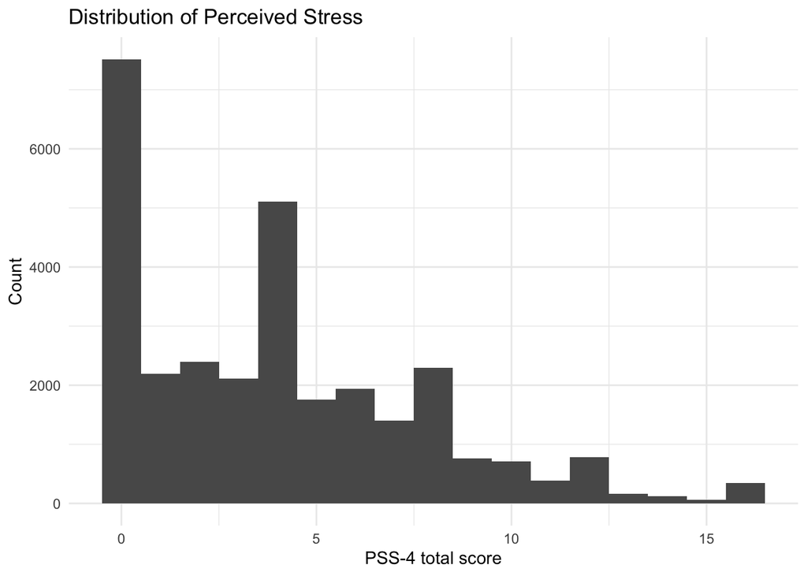

```r
# Histogram
ggplot(model_data, aes(x = pss4_total)) +
  geom_histogram(binwidth = 1) +
  labs(
    title = "Distribution of Perceived Stress",
    x = "PSS-4 total score",
    y = "Count"
  ) +
  theme_minimal()
```

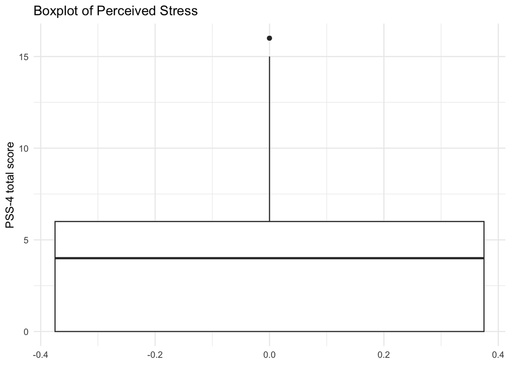

```r
# Boxplot
ggplot(model_data, aes(y = pss4_total)) +
  geom_boxplot() +
  labs(
    title = "Boxplot of Perceived Stress",
    y = "PSS-4 total score"
  ) +
  theme_minimal()
```

```r
# ---------------------------------------------------------
# Step 3. Check skewness and kurtosis of the outcome
# Note:
# OLS does not require Y itself to be normal,
# but this is useful for understanding the shape of the outcome.
# ---------------------------------------------------------
skewness(model_data$pss4_total, na.rm = TRUE, type = 2)
```

```
## [1] 0.8966944
```

```r
kurtosis(model_data$pss4_total, na.rm = TRUE, type = 2)
```

```
## [1] 0.4106812
```

```r
# ---------------------------------------------------------
# Step 4. Fit the OLS model
# ---------------------------------------------------------
m_ols <- lm(
  pss4_total ~ age + gender + education + income_ord + hukou + marital + employment +
    bmi + EQ_VAS + sleep_quality + MEQtotal_new +
    phq9_total + gad7_total + social_support_total + self_efficacy_total +
    resilience_total + family_support_total +
    live_alone + any_life_event + debt_any + ACE_total + drinking + smoking + chronic_disease,
  data = model_data
)

summary(m_ols)
```

```
##
## Call:
## lm(formula = pss4_total ~ age + gender + education + income_ord +
##     hukou + marital + employment + bmi + EQ_VAS + sleep_quality +
##     MEQtotal_new + phq9_total + gad7_total + social_support_total +
##     self_efficacy_total + resilience_total + family_support_total +
##     live_alone + any_life_event + debt_any + ACE_total + drinking +
##     smoking + chronic_disease, data = model_data)
##
## Residuals:
##      Min       1Q   Median       3Q      Max
## -14.8472  -1.3722  -0.4987   1.3021  15.2705
##
## Coefficients:
##                          Estimate Std. Error t value Pr(>|t|)
## (Intercept)             3.5981014  0.2025723  17.762  < 2e-16 ***
## age                    -0.0011742  0.0014473  -0.811  0.41717
## gendermale             -0.0059288  0.0287235  -0.206  0.83647
## education              -0.0486979  0.0087436  -5.570 2.58e-08 ***
## income_ord             -0.0249989  0.0062250  -4.016 5.94e-05 ***
## hukounon-agricultural   0.0258242  0.0282154   0.915  0.36007
## maritalMarried         -0.1118066  0.0895985  -1.248  0.21209
## maritalUnmarried       -0.0354865  0.0944667  -0.376  0.70718
## maritalWidowed         -0.0715616  0.1126981  -0.635  0.52544
## employmentflexible_job  0.0842864  0.0407217   2.070  0.03848 *
## employmentretired      -0.0171354  0.0509615  -0.336  0.73669
## employmentstudent       0.1938722  0.0497958   3.893 9.91e-05 ***
## employmentunemployed    0.0172363  0.0522175   0.330  0.74134
## bmi                     0.0003748  0.0038917   0.096  0.92329
## EQ_VAS                 -0.0039256  0.0007878  -4.983 6.31e-07 ***
## sleep_quality           0.0049595  0.0051934   0.955  0.33961
## MEQtotal_new           -0.0671277  0.0050112 -13.395  < 2e-16 ***
## phq9_total              0.1434282  0.0043883  32.684  < 2e-16 ***
## gad7_total              0.4567276  0.0053248  85.774  < 2e-16 ***
## social_support_total    0.0553963  0.0045747  12.109  < 2e-16 ***
## self_efficacy_total    -0.0973011  0.0073096 -13.311  < 2e-16 ***
## resilience_total       -0.0026232  0.0089303  -0.294  0.76895
## family_support_total   -0.0152667  0.0026278  -5.810 6.32e-09 ***
## live_aloneYes          -0.0509867  0.0376695  -1.354  0.17590
## any_life_eventYes       0.2967414  0.0294628  10.072  < 2e-16 ***
## debt_anyYes             0.0780549  0.0282832   2.760  0.00579 **
## ACE_total               0.0767214  0.0159973   4.796 1.63e-06 ***
## drinkingYes             0.0689176  0.0326421   2.111  0.03475 *
## smokingYes             -0.1765693  0.0393496  -4.487 7.24e-06 ***
## chronic_diseaseYes      0.0083820  0.0327274   0.256  0.79786
## ---
## Signif. codes:  0 '***' 0.001 '**' 0.01 '*' 0.05 '.' 0.1 ' ' 1
##
## Residual standard error: 2.225 on 30021 degrees of freedom
## Multiple R-squared:  0.634,  Adjusted R-squared:  0.6336
## F-statistic:  1793 on 29 and 30021 DF,  p-value: < 2.2e-16
```

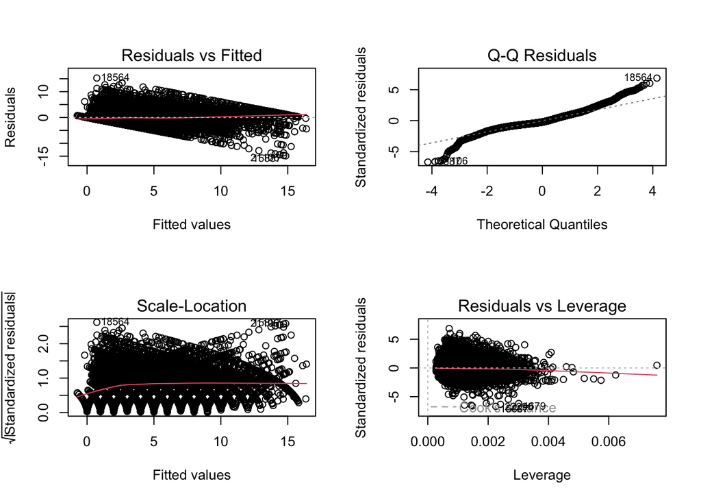

```r
# ---------------------------------------------------------
# Step 5. Standard diagnostic plots
# These are the main plots for checking OLS assumptions
# ---------------------------------------------------------
par(mfrow = c(2, 2))
plot(m_ols)
```

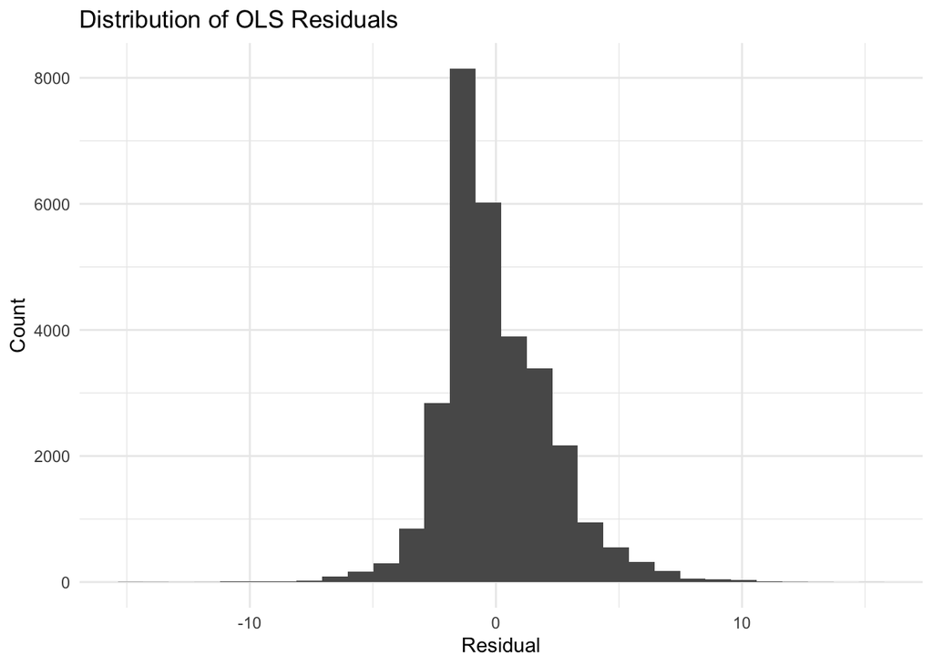

```r
par(mfrow = c(1, 1))

# ---------------------------------------------------------
# Step 6. Check residual normality more directly
# OLS mainly cares about residual behavior, not Y itself
# ---------------------------------------------------------
resid_ols <- residuals(m_ols)

# Histogram of residuals
ggplot(data.frame(resid_ols), aes(x = resid_ols)) +
  geom_histogram(bins = 30) +
  labs(
    title = "Distribution of OLS Residuals",
    x = "Residual",
    y = "Count"
  ) +
  theme_minimal()
```

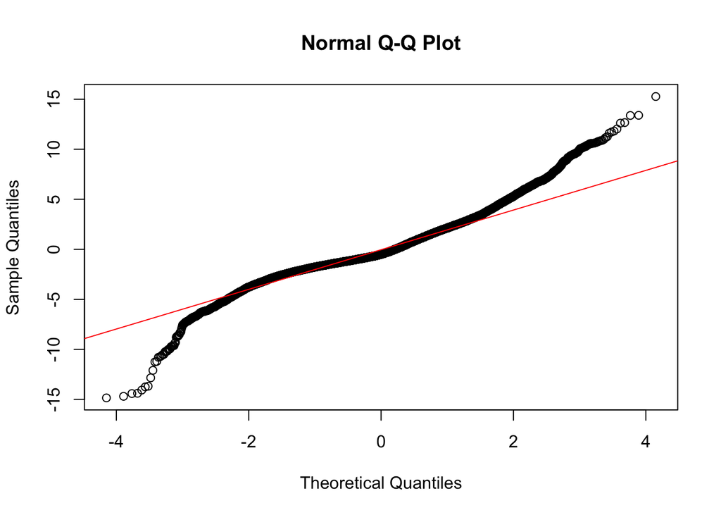

```r
# QQ plot
qqnorm(resid_ols)
qqline(resid_ols, col = "red")
```

```r
# Optional: skewness and kurtosis of residuals
skewness(resid_ols, na.rm = TRUE, type = 2)
```

```
## [1] 0.6378698
```

```r
kurtosis(resid_ols, na.rm = TRUE, type = 2)
```

```
## [1] 2.455372
```

```r
# Optional: Shapiro test
# Not recommended for very large samples because it almost always becomes significant
# shapiro.test(sample(resid_ols, 5000))

# ---------------------------------------------------------
# Step 7. Check heteroskedasticity
# Breusch-Pagan test
# If significant, robust standard errors are recommended
# ---------------------------------------------------------
bptest(m_ols)
```

```
##
##  studentized Breusch-Pagan test
##
## data:  m_ols
## BP = 752.19, df = 29, p-value < 2.2e-16
```

```r
# Robust standard errors
coeftest(m_ols, vcov = vcovHC(m_ols, type = "HC3"))
```

```
##
## t test of coefficients:
##
##                           Estimate  Std. Error  t value  Pr(>|t|)
## (Intercept)             3.59810136  0.21217850  16.9579 < 2.2e-16 ***
## age                    -0.00117423  0.00146163  -0.8034  0.421769
## gendermale             -0.00592883  0.02866837  -0.2068  0.836162
## education              -0.04869786  0.00897367  -5.4268 5.783e-08 ***
## income_ord             -0.02499890  0.00633257  -3.9477 7.909e-05 ***
## hukounon-agricultural   0.02582422  0.02875009   0.8982  0.369070
## maritalMarried         -0.11180655  0.10127613  -1.1040  0.269612
## maritalUnmarried       -0.03548651  0.10560816  -0.3360  0.736858
## maritalWidowed         -0.07156160  0.12253340  -0.5840  0.559213
## employmentflexible_job  0.08428636  0.04091871   2.0598  0.039422 *
## employmentretired      -0.01713543  0.05063341  -0.3384  0.735048
## employmentstudent       0.19387220  0.05190514   3.7351  0.000188 ***
## employmentunemployed    0.01723632  0.05296123   0.3255  0.744842
## bmi                     0.00037476  0.00408352   0.0918  0.926879
## EQ_VAS                 -0.00392558  0.00085468  -4.5930 4.387e-06 ***
## sleep_quality           0.00495946  0.00547380   0.9060  0.364924
## MEQtotal_new           -0.06712772  0.00517987 -12.9593 < 2.2e-16 ***
## phq9_total              0.14342825  0.00595538  24.0838 < 2.2e-16 ***
## gad7_total              0.45672758  0.00696475  65.5771 < 2.2e-16 ***
## social_support_total    0.05539628  0.00494492  11.2027 < 2.2e-16 ***
## self_efficacy_total    -0.09730108  0.00803519 -12.1094 < 2.2e-16 ***
## resilience_total       -0.00262325  0.00924403  -0.2838  0.776583
## family_support_total   -0.01526671  0.00277699  -5.4976 3.882e-08 ***
## live_aloneYes          -0.05098670  0.03917929  -1.3014  0.193142
## any_life_eventYes       0.29674144  0.03009971   9.8586 < 2.2e-16 ***
## debt_anyYes             0.07805485  0.02864852   2.7246  0.006442 **
## ACE_total               0.07672141  0.01715036   4.4735 7.725e-06 ***
## drinkingYes             0.06891756  0.03344349   2.0607  0.039339 *
## smokingYes             -0.17656928  0.04055102  -4.3542 1.340e-05 ***
## chronic_diseaseYes      0.00838198  0.03264294   0.2568  0.797352
## ---
## Signif. codes:  0 '***' 0.001 '**' 0.01 '*' 0.05 '.' 0.1 ' ' 1
```

```r
# ---------------------------------------------------------
# Step 8. Check multicollinearity
# ---------------------------------------------------------
vif(m_ols)
```

```
##                          GVIF Df GVIF^(1/(2*Df))
## age                  3.479762  1        1.865412
## gender               1.252089  1        1.118968
## education            1.990599  1        1.410886
## income_ord           1.240437  1        1.113749
## hukou                1.207337  1        1.098789
## marital              3.215131  3        1.214879
## employment           4.078227  4        1.192090
## bmi                  1.085336  1        1.041795
## EQ_VAS               1.316219  1        1.147266
## sleep_quality        1.240258  1        1.113669
## MEQtotal_new         1.383711  1        1.176313
## phq9_total           3.573108  1        1.890267
## gad7_total           3.515105  1        1.874861
## social_support_total 1.843467  1        1.357743
## self_efficacy_total  1.910492  1        1.382205
## resilience_total     1.519163  1        1.232543
## family_support_total 1.582630  1        1.258026
## live_alone           1.278517  1        1.130715
## any_life_event       1.245502  1        1.116021
## debt_any             1.163464  1        1.078640
## ACE_total            1.186356  1        1.089200
## drinking             1.206527  1        1.098420
## smoking              1.290512  1        1.136007
## chronic_disease      1.421441  1        1.192242
```

```r
# ---------------------------------------------------------
# Step 9. Check influential observations
# ---------------------------------------------------------
cooks_d <- cooks.distance(m_ols)
summary(cooks_d)
```

```
##      Min.   1st Qu.    Median      Mean   3rd Qu.      Max.
## 0.000e+00 3.173e-06 1.101e-05 3.671e-05 3.172e-05 3.860e-03
```

```r
# Common rough rule: observations with Cook's D > 4/n
influential_cases <- which(cooks_d > 4 / nrow(model_data))
length(influential_cases)
```

```
## [1] 1763
```

```r
head(influential_cases)
```

```
##  8 23 27 37 42 45
##  8 23 27 37 42 45
```

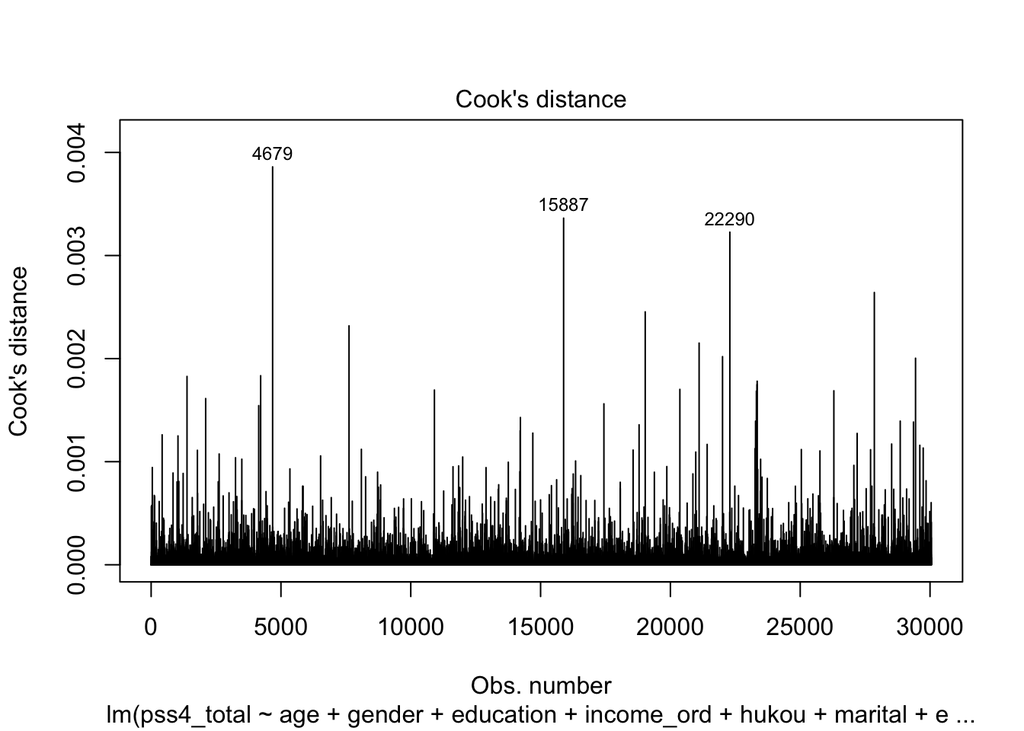

```r
# Influence plots
plot(m_ols, which = 4)  # Cook's distance
```

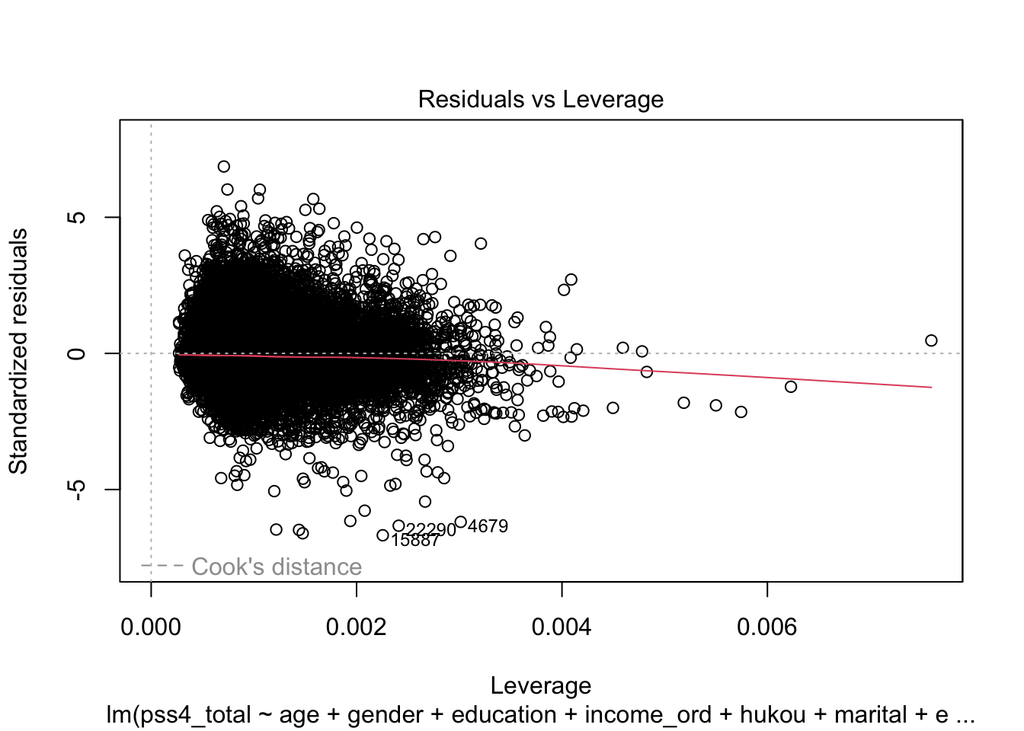

```r
plot(m_ols, which = 5)  # Residuals vs leverage
```

Descriptively, pss4_total exhibits a clearly non-normal distribution. Scores range from 0 to 16, and both the mean and median are around 4. Lower values are heavily concentrated, especially at 0, indicating a possible floor effect. This suggests that perceived stress is generally low in the sample, although meaningful variation still exists across respondents. Although the distribution is not symmetric, the variable still has a reasonably wide range of ordered values and is observed in a large sample, making it acceptable to use as a scale-based continuous outcome in subsequent analysis, with appropriate caution in interpretation.

```r
m_ols <- lm(
    pss4_total ~ age + gender + education + income_ord + hukou + marital + employment +
    bmi + as.numeric(EQ_VAS) + sleep_quality + MEQtotal_new +
    phq9_total + gad7_total + social_support_total + self_efficacy_total +
    resilience_total + family_support_total +
    live_alone + any_life_event + debt_any + ACE_total + drinking + smoking + chronic_disease,
  data = data1
)
summary(m_ols)
```

```
##
## Call:
## lm(formula = pss4_total ~ age + gender + education + income_ord +
##     hukou + marital + employment + bmi + as.numeric(EQ_VAS) +
##     sleep_quality + MEQtotal_new + phq9_total + gad7_total +
##     social_support_total + self_efficacy_total + resilience_total +
##     family_support_total + live_alone + any_life_event + debt_any +
##     ACE_total + drinking + smoking + chronic_disease, data = data1)
##
## Residuals:
##      Min       1Q   Median       3Q      Max
## -14.8472  -1.3722  -0.4987   1.3021  15.2705
##
## Coefficients:
##                          Estimate Std. Error t value Pr(>|t|)
## (Intercept)             3.5981014  0.2025723  17.762  < 2e-16 ***
## age                    -0.0011742  0.0014473  -0.811  0.41717
## gendermale             -0.0059288  0.0287235  -0.206  0.83647
## education              -0.0486979  0.0087436  -5.570 2.58e-08 ***
## income_ord             -0.0249989  0.0062250  -4.016 5.94e-05 ***
## hukounon-agricultural   0.0258242  0.0282154   0.915  0.36007
## maritalMarried         -0.1118066  0.0895985  -1.248  0.21209
## maritalUnmarried       -0.0354865  0.0944667  -0.376  0.70718
## maritalWidowed         -0.0715616  0.1126981  -0.635  0.52544
## employmentflexible_job  0.0842864  0.0407217   2.070  0.03848 *
## employmentretired      -0.0171354  0.0509615  -0.336  0.73669
## employmentstudent       0.1938722  0.0497958   3.893 9.91e-05 ***
## employmentunemployed    0.0172363  0.0522175   0.330  0.74134
## bmi                     0.0003748  0.0038917   0.096  0.92329
## as.numeric(EQ_VAS)     -0.0039256  0.0007878  -4.983 6.31e-07 ***
## sleep_quality           0.0049595  0.0051934   0.955  0.33961
## MEQtotal_new           -0.0671277  0.0050112 -13.395  < 2e-16 ***
## phq9_total              0.1434282  0.0043883  32.684  < 2e-16 ***
## gad7_total              0.4567276  0.0053248  85.774  < 2e-16 ***
## social_support_total    0.0553963  0.0045747  12.109  < 2e-16 ***
## self_efficacy_total    -0.0973011  0.0073096 -13.311  < 2e-16 ***
## resilience_total       -0.0026232  0.0089303  -0.294  0.76895
## family_support_total   -0.0152667  0.0026278  -5.810 6.32e-09 ***
## live_aloneYes          -0.0509867  0.0376695  -1.354  0.17590
## any_life_eventYes       0.2967414  0.0294628  10.072  < 2e-16 ***
## debt_anyYes             0.0780549  0.0282832   2.760  0.00579 **
## ACE_total               0.0767214  0.0159973   4.796 1.63e-06 ***
## drinkingYes             0.0689176  0.0326421   2.111  0.03475 *
## smokingYes             -0.1765693  0.0393496  -4.487 7.24e-06 ***
## chronic_diseaseYes      0.0083820  0.0327274   0.256  0.79786
## ---
## Signif. codes:  0 '***' 0.001 '**' 0.01 '*' 0.05 '.' 0.1 ' ' 1
##
## Residual standard error: 2.225 on 30021 degrees of freedom
##   (3 observations deleted due to missingness)
## Multiple R-squared:  0.634,  Adjusted R-squared:  0.6336
## F-statistic:  1793 on 29 and 30021 DF,  p-value: < 2.2e-16
```

```r
library(lmtest)
library(sandwich)

# Breusch-Pagan test for heteroskedasticity
bptest(m_ols)
```

```
##
##  studentized Breusch-Pagan test
##
## data:  m_ols
## BP = 752.19, df = 29, p-value < 2.2e-16
```

```r
# OLS coefficients with HC3 robust standard errors
coeftest(m_ols, vcov = vcovHC(m_ols, type = "HC3"))
```

```
##
## t test of coefficients:
##
##                           Estimate  Std. Error  t value  Pr(>|t|)
## (Intercept)             3.59810136  0.21217850  16.9579 < 2.2e-16 ***
## age                    -0.00117423  0.00146163  -0.8034  0.421769
## gendermale             -0.00592883  0.02866837  -0.2068  0.836162
## education              -0.04869786  0.00897367  -5.4268 5.783e-08 ***
## income_ord             -0.02499890  0.00633257  -3.9477 7.909e-05 ***
## hukounon-agricultural   0.02582422  0.02875009   0.8982  0.369070
## maritalMarried         -0.11180655  0.10127613  -1.1040  0.269612
## maritalUnmarried       -0.03548651  0.10560816  -0.3360  0.736858
## maritalWidowed         -0.07156160  0.12253340  -0.5840  0.559213
## employmentflexible_job  0.08428636  0.04091871   2.0598  0.039422 *
## employmentretired      -0.01713543  0.05063341  -0.3384  0.735048
## employmentstudent       0.19387220  0.05190514   3.7351  0.000188 ***
## employmentunemployed    0.01723632  0.05296123   0.3255  0.744842
## bmi                     0.00037476  0.00408352   0.0918  0.926879
## as.numeric(EQ_VAS)     -0.00392558  0.00085468  -4.5930 4.387e-06 ***
## sleep_quality           0.00495946  0.00547380   0.9060  0.364924
## MEQtotal_new           -0.06712772  0.00517987 -12.9593 < 2.2e-16 ***
## phq9_total              0.14342825  0.00595538  24.0838 < 2.2e-16 ***
## gad7_total              0.45672758  0.00696475  65.5771 < 2.2e-16 ***
## social_support_total    0.05539628  0.00494492  11.2027 < 2.2e-16 ***
## self_efficacy_total    -0.09730108  0.00803519 -12.1094 < 2.2e-16 ***
## resilience_total       -0.00262325  0.00924403  -0.2838  0.776583
## family_support_total   -0.01526671  0.00277699  -5.4976 3.882e-08 ***
## live_aloneYes          -0.05098670  0.03917929  -1.3014  0.193142
## any_life_eventYes       0.29674144  0.03009971   9.8586 < 2.2e-16 ***
## debt_anyYes             0.07805485  0.02864852   2.7246  0.006442 **
## ACE_total               0.07672141  0.01715036   4.4735 7.725e-06 ***
## drinkingYes             0.06891756  0.03344349   2.0607  0.039339 *
## smokingYes             -0.17656928  0.04055102  -4.3542 1.340e-05 ***
## chronic_diseaseYes      0.00838198  0.03264294   0.2568  0.797352
## ---
## Signif. codes:  0 '***' 0.001 '**' 0.01 '*' 0.05 '.' 0.1 ' ' 1
```

Lasso:

```r
# =========================================================
# LASSO for predicting pss4_total
# Purpose:
# 1. Use the same set of predictors as in the OLS model.
# 2. Apply LASSO with cross-validation to shrink less useful
#    coefficients toward zero.
# 3. Identify which predictors remain important after penalty.
# =========================================================

library(dplyr)
library(glmnet)
# ---------------------------------------------------------
# Step 1. Create analysis data with the same variables used in OLS
# This ensures that LASSO is fit on the same specification.
# ---------------------------------------------------------
lasso_data <- data1 |>
  select(
    pss4_total,
    age, gender, education, income_ord, hukou, marital, employment,
    bmi, EQ_VAS, sleep_quality, MEQtotal_new,
    phq9_total, gad7_total, social_support_total, self_efficacy_total,
    resilience_total, family_support_total,
    live_alone, any_life_event, debt_any, ACE_total,
    drinking, smoking, chronic_disease
  ) |>
  filter(if_all(everything(), ~ !is.na(.)))

# Make categorical predictors factors
lasso_data$gender <- as.factor(lasso_data$gender)
lasso_data$hukou <- as.factor(lasso_data$hukou)
lasso_data$marital <- as.factor(lasso_data$marital)
lasso_data$employment <- as.factor(lasso_data$employment)
lasso_data$live_alone <- as.factor(lasso_data$live_alone)
lasso_data$any_life_event <- as.factor(lasso_data$any_life_event)
lasso_data$debt_any <- as.factor(lasso_data$debt_any)
lasso_data$drinking <- as.factor(lasso_data$drinking)
lasso_data$smoking <- as.factor(lasso_data$smoking)
lasso_data$chronic_disease <- as.factor(lasso_data$chronic_disease)

# ---------------------------------------------------------
# Step 2. Create design matrix
# model.matrix() converts factors into dummy variables, which
# glmnet needs. The intercept column is removed because glmnet
# handles the intercept internally.
# ---------------------------------------------------------
x <- model.matrix(
  pss4_total ~ age + gender + education + income_ord + hukou + marital + employment +
    bmi + as.numeric(EQ_VAS) + sleep_quality + MEQtotal_new +
    phq9_total + gad7_total + social_support_total + self_efficacy_total +
    resilience_total + family_support_total +
    live_alone + any_life_event + debt_any + ACE_total + drinking + smoking + chronic_disease,
  data = lasso_data
)[, -1]

y <- lasso_data$pss4_total

# ---------------------------------------------------------
# Step 3. Run cross-validated LASSO
# alpha = 1 means LASSO penalty.
# nfolds = 10 gives 10-fold cross-validation.
# standardize = TRUE is recommended because predictors are on
# different scales.
# ---------------------------------------------------------
set.seed(123)

cv_lasso <- cv.glmnet(
  x = x,
  y = y,
  alpha = 1,
  nfolds = 10,
  standardize = TRUE
)

# View the optimal penalty values
cv_lasso$lambda.min   # lambda giving minimum CV error
```

```
## [1] 0.004247656
```

```r
cv_lasso$lambda.1se   # more conservative lambda
```

```
## [1] 0.06922621
```

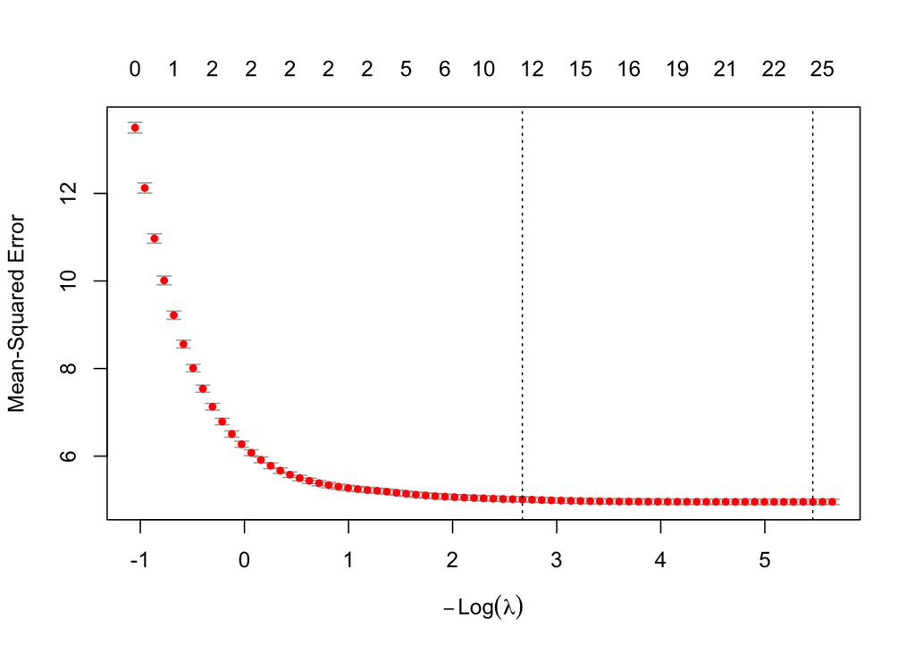

```r
# Plot CV curve
plot(cv_lasso)
```

```r
# ---------------------------------------------------------
# Step 4. Extract coefficients
# lambda.min keeps more variables;
# lambda.1se is more parsimonious.
# ---------------------------------------------------------
coef_min <- coef(cv_lasso, s = "lambda.min")
coef_1se <- coef(cv_lasso, s = "lambda.1se")

coef_min
```

```
## 30 x 1 sparse Matrix of class "dgCMatrix"
##                           lambda.min
## (Intercept)             3.5228330155
## age                    -0.0008440364
## gendermale              .
## education              -0.0442250835
## income_ord             -0.0241456570
## hukounon-agricultural   0.0078819007
## maritalMarried         -0.0608271265
## maritalUnmarried        0.0004318441
## maritalWidowed         -0.0024330860
## employmentflexible_job  0.0712926726
## employmentretired      -0.0159940822
## employmentstudent       0.1925091748
## employmentunemployed    0.0011916614
## bmi                     .
## as.numeric(EQ_VAS)     -0.0037771844
## sleep_quality           0.0021608620
## MEQtotal_new           -0.0665198524
## phq9_total              0.1427143647
## gad7_total              0.4567841467
## social_support_total    0.0516522821
## self_efficacy_total    -0.0940633508
## resilience_total       -0.0005459879
## family_support_total   -0.0144259431
## live_aloneYes          -0.0343856321
## any_life_eventYes       0.2952127548
## debt_anyYes             0.0708495134
## ACE_total               0.0729389469
## drinkingYes             0.0535338561
## smokingYes             -0.1605161450
## chronic_diseaseYes      .
```